# Introdução à economia

Aula 26 - Inflação

Prof. Roberto de Freitas Neder

## Aula 26: roteiro

**Inflação** · Mankiw, capítulo 30 · UnB

- Inflação e seus mecanismos
- Teoria clássica e equação quantitativa
- Imposto inflacionário, juros e custos
- Brasil: de 1945 a 1984
- Planos de estabilização
- Plano Real e URV
- Governos de FHC a Lula
- Israel, México e regime de metas
- Conclusão
- Exercícios de concursos públicos

Use as setas para trocar de slide. Os exemplos numéricos são didáticos, salvo indicação expressa. As questões e respostas comentadas ficam na página final, com rolagem. Dados atualizados até 06/11/2026.

## 01 - Inflação: preços, índices e poder de compra

**Inflação** é o aumento do nível geral de preços. Não exige que todos os preços subam, nem significa que um único produto mais caro represente a inflação de toda a economia.

$$\pi_t=\left(\frac{P_t}{P_{t-1}}-1\right)\times100$$

| Situação | Significado |
| --- | --- |
| Inflação de 6% | O índice passa de 100 para 106 |
| Desinflação para 3% | Os preços continuam subindo, agora mais devagar |
| Deflação de 2% | O nível geral de preços diminui |

O **IPCA**, calculado pelo IBGE, é o índice usado nas metas brasileiras. Índices têm cestas e populações distintas; a inflação de cada família pode diferir da média.

**Referência teórica:** Mankiw, capítulo 30, *Money Growth and Inflation*, pp. 627 a 650. Fonte complementar: [IBGE, IPCA](https://www.ibge.gov.br/estatisticas/economicas/precos-e-custos/9256-ipca.html).

← Menu

## 02 - Tipos de inflação: mecanismos que podem coexistir

| Mecanismo | Ideia central | Exemplo |
| --- | --- | --- |
| Demanda | Gasto cresce além da capacidade de resposta da oferta | Consumo e investimento pressionam uma economia próxima de sua capacidade |
| Custos ou oferta | Insumos encarecem ou a produção disponível diminui | Petróleo, câmbio depreciado, seca e energia |
| Inercial | Reajustes reproduzem a inflação passada | Contratos e salários indexados |
| Expectativas e conflito distributivo | Agentes antecipam aumentos e tentam preservar renda ou margens | Reajustes preventivos e disputa pela distribuição do produto |

São diagnósticos complementares. A análise estrutural destaca gargalos produtivos, infraestrutura e dependência externa. **O choque inicial e sua propagação são questões diferentes.**

Inflação antecipada ou inesperada é outra classificação, importante para os efeitos sobre contratos e patrimônio.

← Menu

## 03 - Teoria clássica: o valor da moeda

Quanto maior o nível de preços $P$, menor o poder de compra de cada unidade monetária: **valor da moeda = $1/P$**.

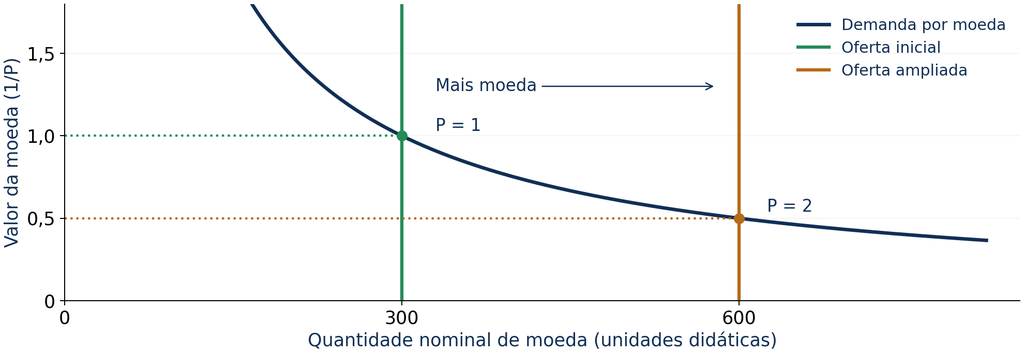

No modelo clássico, a expansão da oferta monetária reduz o valor da moeda, dadas a demanda por saldos reais e a produção.

O gráfico isola um modelo: com produção real e demanda por saldos reais dadas, mais moeda leva a um nível de preços maior. A oferta vertical é uma **simplificação analítica**, não uma descrição da operação diária do Copom.

← Menu

## 04 - Equação quantitativa: identidade e hipótese

$$MV=PY\qquad V=\frac{PY}{M}$$

$M$ é o estoque de moeda; $V$, sua velocidade de circulação; $P$, o nível de preços; $Y$, a produção real. $PY$ é o produto nominal.

A equação é uma identidade quando $V$ é definido por essa razão. A **teoria quantitativa** acrescenta hipóteses: velocidade relativamente estável e produto real determinado, no longo prazo, por fatores reais.

$$\pi\approx g_M+g_V-g_Y$$

**Exemplo didático:** moeda cresce 8%, produto real cresce 3% e velocidade não muda. A inflação aproximada é 5%. Pelo cálculo composto, $1{,}08/1{,}03-1\approx4{,}85\%$.

Não se pode inferir inflação proporcional à moeda sem examinar as hipóteses.

← Menu

## 05 - Ajustamento, dicotomia e neutralidade

Após uma expansão monetária, os agentes podem ter mais saldos que desejam manter. Tentam gastar ou adquirir ativos; preços e decisões se ajustam até a demanda por moeda se compatibilizar com a oferta.

**Dicotomia clássica:** separação analítica entre variáveis nominais, como preços e salários em reais, e reais, como produção, emprego e salário em bens.

**Neutralidade monetária:** no modelo de longo prazo, aumentar proporcionalmente a quantidade de moeda altera variáveis nominais, sem elevar permanentemente a produção real.

No curto prazo, rigidez de preços, contratos, crédito e expectativas podem gerar efeitos sobre atividade e emprego. O capítulo reconhece esses custos de transição.

Uma elevação única do nível de moeda não implica, por si só, inflação continuamente elevada.

← Menu

## 06 - Hiperinflação, senhoriagem e imposto inflacionário

Mankiw utiliza como referência para **hiperinflação** aumentos de preços superiores a 50% ao mês. Nesses episódios, a perda de confiança pode acelerar a circulação e reduzir a demanda por moeda.

**Senhoriagem** é o recurso real obtido com a emissão monetária. **Imposto inflacionário** é a perda de poder de compra dos saldos monetários sem proteção contra a inflação. São relacionados, mas não idênticos.

Se alguém mantém R$ 100 sem rendimento e os preços sobem 10%, seu saldo passa a comprar o equivalente a **R$ 90,91 aos preços iniciais**.

No modelo do capítulo, déficits financiados repetidamente por emissão podem alimentar a inflação. Não se conclui que qualquer déficit gere automaticamente inflação: financiamento, capacidade produtiva e regime monetário importam.

Quem tem menos acesso a proteção financeira tende a sofrer mais com a manutenção de saldos desprotegidos.

← Menu

## 07 - Efeito Fisher: juros nominais e reais

$$i\approx r+\pi^e$$

$i$ é o juro nominal, $r$ o juro real esperado e $\pi^e$ a inflação esperada. No longo prazo, mantido o juro real, maior inflação esperada tende a elevar o juro nominal.

Para o retorno real efetivamente obtido, usamos a inflação realizada:

$$1+r_{\mathrm{realizado}}=\frac{1+i}{1+\pi}$$

**Exemplo:** aplicação rende 10% e a inflação é 6%. O ganho real é aproximadamente 4%, ou **3,77% pelo cálculo exato**.

O efeito Fisher não significa que toda alta observada de juros seja causada pela inflação. A política monetária também pode elevar o juro real para conter a demanda.

← Menu

## 08 - Custos da inflação: além do preço mais alto

| Custo apresentado por Mankiw | Consequência |
| --- | --- |
| “Sola de sapato” | Tempo e recursos para reduzir saldos monetários e administrar pagamentos |
| Custos de menu | Alteração de etiquetas, sistemas, contratos e tabelas de preços |
| Distorção de preços relativos | Reajustes em momentos diferentes confundem sinais de escassez |
| Distorções tributárias | Impostos podem incidir sobre ganhos apenas nominais |
| Confusão e inconveniência | A unidade monetária fica menos útil para comparar valores no tempo |
| Redistribuição inesperada | Contratos nominais transferem patrimônio entre devedores e credores |

**A “falácia da inflação”:** não basta imaginar preços subindo com todas as rendas permanentemente fixas. Preços também são receitas. Os custos relevantes envolvem ajustes desiguais, incerteza, distorções e perdas de eficiência.

Isso não nega perdas reais de quem recebe renda com reajuste atrasado ou incompleto.

← Menu

## 09 - Contratos, impostos e desigualdade

**Inflação inesperadamente alta** reduz o valor real de uma dívida nominal prefixada: tende a beneficiar o devedor e prejudicar o credor. O resultado depende das cláusulas, da indexação e da inflação já prevista no contrato.

**Exemplo tributário hipotético:** aplicação rende 10%, inflação é 8% e o imposto é 20% do rendimento nominal. Depois do imposto, o rendimento cai a 8%: o ganho real é zero.

Salários, aposentadorias, aluguéis e aplicações não se reajustam simultaneamente. Famílias também consomem cestas diferentes.

**Conexão com o curso:** a inflação pode alterar a distribuição de renda e riqueza mesmo sem mudar imediatamente a produção. Avaliar a média de preços não substitui examinar quem está exposto e quem consegue se proteger.

← Menu

## 10 - Por que deflação também pode ser um problema?

Uma queda persistente e inesperada dos preços aumenta o peso real das dívidas nominais. Dificuldades de pagamento podem atingir crédito, investimento e emprego.

Se os preços caem e o juro nominal está próximo de seu limite inferior, o juro real pode permanecer elevado. A política monetária encontra mais dificuldade para estimular a economia.

Uma redução isolada de preços por ganho de produtividade não é equivalente a uma deflação generalizada associada à contração da demanda.

**Estabilizar não é fazer todos os preços voltarem ao passado.** O objetivo é reduzir a inflação de forma duradoura, considerando também os custos da transição para produção e emprego.

No capítulo, a experiência americana do século XIX ilustra como a deflação agravou dívidas e alimentou conflitos sobre o padrão monetário.

← Menu

## 11 - 1945 a 1964: desenvolvimento e restrições

Em 1945, a transição do Estado Novo ao pós-guerra encontrou uma economia em industrialização, com restrições de oferta e de acesso a divisas.

| Governos | Estrutura e inflação | Respostas essenciais |
| --- | --- | --- |
| Dutra, 1946 a 1951 | Pressões do pós-guerra e perda de reservas externas | Abertura inicial às importações; depois controles cambiais e contenção de gastos e salários |
| Vargas e Café Filho, 1951 a 1955 | Gargalos de energia, transportes e setor externo; pressões distributivas | Investimento estrutural e tentativas de estabilização fiscal e monetária |
| JK, 1956 a 1961 | Plano de Metas acelera investimento; financiamento e importações pressionam a economia | Plano de Estabilização Monetária, de 1958; prioridade política ao desenvolvimento |
| Jânio e Goulart, 1961 a 1964 | Inflação se acelera em meio a restrição externa e conflito político | Ajuste inicial; depois Plano Trienal, articulando estabilização e reformas, sem êxito duradouro |

Fontes: FGV/CPDOC, [Dutra](https://cpdoc.fgv.br/biografias/eurico-gaspar-dutra), [Vargas](https://cpdoc.fgv.br/getulio-vargas-1954/politica-de-desenvolvimento), [JK](https://cpdoc.fgv.br/biografias/juscelino-kubitschek-0) e [Goulart](https://cpdoc.fgv.br/biografias/joao-goulart).

← Menu

## 12 - 1964 a 1984: ajuste, indexação e dívida

| Governos | Estrutura e inflação | Respostas e limites |
| --- | --- | --- |
| Castelo Branco, 1964 a 1967 | Inflação elevada e desequilíbrios de financiamento | PAEG: ajuste fiscal, crédito e salários; reformas tributária e financeira; correção monetária |
| Costa e Silva e Médici, 1967 a 1974 | Crescimento acelerado e queda inicial da inflação; dependência de petróleo e financiamento externo | Expansão do crédito e controle de preços; compressão salarial e concentração de renda |
| Geisel, 1974 a 1979 | Primeiro choque do petróleo; inflação e restrição externa | II PND: energia, insumos básicos e bens de capital, financiados também por dívida externa |
| Figueiredo, 1979 a 1985; recorte até 1984 | Novo choque do petróleo, juros externos altos e crise da dívida; indexação propaga aumentos | Desvalorizações, ajuste externo e recessão no início dos anos 1980, sem interromper a inflação |

**Herança para os planos seguintes:** inflação elevada, contratos indexados, conflito distributivo e fragilidade fiscal e externa. A indexação protegia contratos, mas também transmitia inflação passada.

Fontes: [Simonsen, inflação brasileira (1985)](https://www.scielo.br/j/rep/a/RY6Q9jdwtSH3CSmhdbPJ5yj/?lang=pt), [FGV, PAEG](https://atlas.fgv.br/verbete/1205) e [Figueiredo](https://atlas.fgv.br/verbete/2016).

← Menu

## 13 - Sarney, 1985 a 1990: congelar não bastou

**Diagnóstico:** forte componente inercial em uma economia indexada, somado a desequilíbrios fiscais, externos e disputas por recomposição de renda.

| Plano | Medidas centrais | Resultado e limites |
| --- | --- | --- |
| Cruzado, fevereiro de 1986 | Nova moeda, congelamento de preços, conversão salarial e gatilho | Queda inicial da inflação; demanda aquecida, preços relativos desalinhados, escassez e ágio |
| Cruzado II, novembro de 1986 | Correção de tarifas e preços; elevação de tributos | Retomada dos reajustes e perda de sustentação do congelamento |
| Bresser, junho de 1987 | Congelamento temporário, ajuste fiscal anunciado e nova regra salarial | Alívio breve, sem coordenação duradoura dos reajustes e do financiamento |
| Verão, janeiro de 1989 | Cruzado novo, congelamento e tentativa de desindexação | Inflação volta a acelerar; indexação informal e perda de confiança |

**IPCA anual:** 79,66% em 1986; 1.972,91% em 1989. A queda inicial de um índice não demonstra estabilização sustentável.

Fontes: [BCB, história dos planos](https://www.bcb.gov.br/controleinflacao/30anosreal) e [IBGE/Sidra, tabela 1737](https://sidra.ibge.gov.br/tabela/1737).

← Menu

## 14 - Collor, 1990 a 1992: o choque de liquidez

**Plano Collor I, março de 1990:** bloqueio de grande parte dos ativos financeiros, limitado o acesso imediato a saldos; retorno do cruzeiro; medidas sobre preços, salários, tributos e abertura comercial.

A intenção era retirar liquidez e interromper a inflação. O bloqueio atingiu pagamentos e capital de giro, contribuiu para a recessão e comprometeu a confiança. Liberações, recomposição da liquidez e persistência de mecanismos de reajuste limitaram a estabilização.

**Collor II, janeiro de 1991:** novo congelamento e mudanças na indexação financeira e nas regras de remuneração. Também não produziu estabilidade duradoura.

**IPCA anual:** 1.620,97% em 1990; 472,70% em 1991; 1.119,10% em 1992. São anos-calendário: 1990 e 1992 incluem transições presidenciais.

**Lição:** reduzir abruptamente a liquidez pode provocar forte custo real sem resolver todos os mecanismos que reproduzem a inflação.

Fontes: [Bresser-Pereira e Nakano, análise do Plano Collor](https://www.scielo.br/j/rep/a/b8tSwspPSzWrVcC6N9wWy7Q/?lang=pt), [FGV, planos Collor](https://atlas.fgv.br/verbete/6296) e [IBGE/Sidra](https://sidra.ibge.gov.br/tabela/1737).

← Menu

## 15 - Itamar, 1992 a 1994: as etapas do Plano Real

O Real foi implantado **no governo Itamar Franco**, com FHC como ministro da Fazenda na elaboração inicial e uma equipe econômica que deu continuidade à execução.

| Etapa | Mecanismo | Problema enfrentado |
| --- | --- | --- |
| Preparação fiscal, 1993 a 1994 | Programa de Ação Imediata e Fundo Social de Emergência | Dar sustentação financeira à estabilização; não significou solução definitiva das contas públicas |
| URV, março a junho de 1994 | Preços e contratos passam a uma referência comum; pagamentos seguem em cruzeiros reais | Coordenar reajustes e reduzir a reprodução da inflação passada |
| Real, julho de 1994 | Conversão da URV em moeda: 1 URV = R$ 1 = CR$ 2.750 na conversão | Unificar unidade de conta e meio de pagamento |

A estratégia não se baseou em congelamento geral de preços nem em bloqueio de depósitos. Câmbio, importações e restrição monetária ajudaram a sustentar a desinflação após a conversão.

Fonte: [BCB, Plano Real](https://www.bcb.gov.br/controleinflacao/planoreal).

← Menu

## 16 - Plano Real: como a URV ajudou e o que mudou

**A URV era a referência do preço; o pagamento era feito em cruzeiros reais.** Exemplo: mantendo um produto a **10 URV**, paga-se **CR$ 10.000** quando **1 URV = CR$ 1.000**, ou **CR$ 20.000** quando **1 URV = CR$ 2.000**. A cotação da URV era reajustada diariamente para acompanhar a inflação: mais cruzeiros reais eram necessários para pagar o mesmo preço em URV.

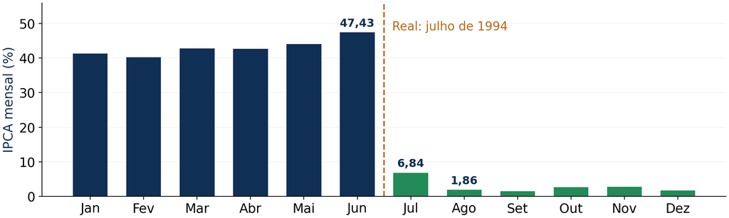

IPCA mensal em 1994, com queda acentuada após a entrada do real em julho.

A URV facilitou a coordenação dos preços, mas a estabilização exigiu sustentação econômica. O IPCA foi **47,43% em junho**, **6,84% em julho** e **1,86% em agosto**. O acumulado de 1994 ainda foi 916,46%, pois inclui os meses anteriores ao real.

Fontes: [BCB, Plano Real](https://www.bcb.gov.br/controleinflacao/planoreal) e [IBGE/Sidra, IPCA mensal](https://sidra.ibge.gov.br/tabela/1737). Gráfico autoral com dados oficiais.

← Menu

## 17 - FHC, 1995 a 2002: da âncora cambial às metas

**Estrutura:** consolidação da estabilidade, maior integração financeira e vulnerabilidade às crises externas. Câmbio valorizado barateava importados, mas pressionava a competitividade e as contas externas.

**Respostas:** manutenção inicial da âncora cambial e juros elevados. Após pressões sobre reservas, o câmbio passou a flutuar em janeiro de 1999. Em junho, foi instituído o regime de metas para a inflação, articulado a metas fiscais.

**Resultados:** IPCA de 22,41% em 1995; 1,65% em 1998; 8,94% em 1999; 12,53% em 2002. A depreciação cambial e a incerteza financeira pressionaram os preços em 2002.

**Balanço:** estabilização duradoura, com mudança da âncora monetária. Juros altos, fragilidade externa e custos de ajuste exigem ser considerados junto ao benefício da inflação menor.

Fontes: [BCB, histórico das metas](https://www.bcb.gov.br/controleinflacao/historicometas), [Copom, janeiro de 2003](https://www.bcb.gov.br/htms/copom/not2003012280.asp?frame=1) e [IBGE/Sidra](https://sidra.ibge.gov.br/tabela/1737).

← Menu

## 18 - Lula, 2003 a 2010: continuidade e novos choques

**Estrutura:** inflação e expectativas pressionadas no início de 2003; posteriormente, expansão econômica, melhora externa e valorização cambial. A alta internacional de alimentos e energia trouxe novas pressões em 2007 e 2008.

**Respostas:** preservação das metas de inflação e do câmbio flutuante; aperto monetário inicial e compromisso fiscal. O BC adaptou a velocidade de convergência aos efeitos herdados de 2002. Depois, a política respondeu a choques de commodities e à crise mundial.

**Resultados:** IPCA de 9,30% em 2003; 3,14% em 2006; 5,90% em 2008; 5,91% em 2010.

**Leitura econômica:** crescimento e políticas distributivas coexistiram com inflação muito menor que a anterior ao Real. A trajetória também dependeu do câmbio, da oferta e do ambiente internacional.

Fontes: [BCB, carta referente a 2003](https://www.bcb.gov.br/content/controleinflacao/controleinflacao_docs/carta_aberta/carta2003.pdf), [commodities e inflação](https://www.bcb.gov.br/htms/relinf/port/2011/06/ri201106b4p.pdf) e [IBGE/Sidra](https://sidra.ibge.gov.br/tabela/1737).

← Menu

## 19 - Dilma, 2011 a 2016: preços represados e correções

**Estrutura:** inflação de serviços persistente, choques de alimentos e deterioração das condições econômicas. A contenção de determinados preços administrados reduziu a inflação medida inicialmente, mas adiou parte do ajuste.

**Respostas:** redução de juros em uma primeira fase, desonerações e medidas sobre tarifas; posteriormente, aperto monetário e realinhamento de preços. Em 2015, energia e outros administrados subiram, junto à depreciação cambial.

**Resultados:** IPCA de 6,50% em 2011; 6,41% em 2014; **10,67% em 2015**. A aceleração de 2015 ocorreu junto à recessão, mostrando que inflação não resulta apenas de excesso de demanda.

**Limite:** adiar reajustes pode reduzir temporariamente o índice, mas produz custos fiscais ou empresariais e necessidade de correção posterior. O ano de 2016 abrange Dilma e Temer.

Fontes: [BCB, política monetária em 2013](https://www.bcb.gov.br/Pre/Surel/RelAdmBC/2013/relatorio-de-atividades/panorama-da-economia-em-2012/politica-monetaria.html), [carta de 2015](https://www.bcb.gov.br/content/monetarypolicy/openletters/carta2015.pdf) e [IBGE/Sidra](https://sidra.ibge.gov.br/tabela/1737).

← Menu

## 20 - Temer, 2016 a 2018: desinflação e oferta agrícola

**Estrutura:** recuperação lenta após a recessão, elevada ociosidade e desemprego. Em 2017, choques favoráveis na oferta de alimentos contribuíram fortemente para a inflação menor.

**Respostas:** manutenção das metas; redução gradual da Selic conforme inflação e expectativas recuavam. O governo adotou o teto de gastos como regra fiscal, buscando sinalizar contenção da despesa.

**Resultados:** IPCA de 6,29% em 2016, ano compartilhado com Dilma; **2,95% em 2017**, abaixo do piso de 3%; 3,75% em 2018.

**Leitura econômica:** a queda não pode ser atribuída somente à mudança de governo ou a uma regra fiscal. Demanda fraca, efeitos defasados dos juros e oferta de alimentos também importaram. A meta possui limite inferior e superior.

Fontes: [BCB, estudos especiais, decomposição de 2017](https://www.bcb.gov.br/publicacoes/estudosespeciais), [histórico de metas](https://www.bcb.gov.br/controleinflacao/historicometas) e [IBGE/Sidra](https://sidra.ibge.gov.br/tabela/1737).

← Menu

## 21 - Bolsonaro, 2019 a 2022: pandemia, energia e tributos

**Estrutura:** pandemia, mudanças no consumo, gargalos de produção, câmbio e commodities; crise hídrica em 2021 e guerra na Ucrânia em 2022 pressionaram energia e alimentos.

**Respostas:** juros baixos e medidas emergenciais na crise inicial; forte alta da Selic a partir de 2021. Em 2022, reduções de tributos sobre combustíveis, energia e outros itens contribuíram para diminuir o índice.

**Resultados:** IPCA de 4,31% em 2019; 4,52% em 2020; **10,06% em 2021**; 5,79% em 2022. Os dois últimos resultados ficaram acima do teto das respectivas metas.

**Limite:** a redução de um tributo pode baixar o nível de preços uma vez; sustentar desinflação exige avaliar os demais mecanismos. Inflação agregada menor também pode coexistir com alimentos ainda caros.

Fontes: [BCB, resultados de 2022](https://www.bcb.gov.br/publicacoes/rig22-nossosresultados), [IBGE, fechamento de 2022](https://agenciadenoticias.ibge.gov.br/agencia-sala-de-imprensa/2013-agencia-de-noticias/releases/36047-ipca-vai-a-0-62-em-dezembro-e-fecha-2022-em-5-79) e [Sidra](https://sidra.ibge.gov.br/tabela/1737).

← Menu

## 22 - Lula, desde 2023: inflação e meta contínua

**Estrutura:** desinflação em 2023, novas pressões de alimentos, energia e câmbio em momentos posteriores; persistência de serviços e efeitos de choques climáticos e externos.

**Respostas:** novo arcabouço fiscal em 2023; mudanças de tributação e medidas setoriais. A política monetária, decidida pelo BCB autônomo, passou por cortes e novo aperto conforme as perspectivas de inflação. Em 2025 entrou em vigor a meta contínua.

| Período | IPCA |
| --- | --- |
| 2023, ano completo | 4,62% |
| 2024, ano completo | 4,83% |
| 2025, ano completo | 4,26% |
| Setembro de 2026, acumulado em 12 meses | 4,58% |

**Corte da aula: 06/11/2026.** O último resultado completo disponível é setembro; 4,58% não é a inflação anual fechada de 2026. Um mês fora da faixa não basta, sozinho, para caracterizar descumprimento na regra contínua.

Fontes: [arcabouço fiscal, 2023](https://www12.senado.leg.br/noticias/materias/2023/08/31/novo-arcabouco-fiscal-entra-em-vigencia-no-brasil), [IBGE/Sidra](https://sidra.ibge.gov.br/tabela/1737), [Ipea, análise de outubro de 2026](https://www.ipea.gov.br/cartadeconjuntura/index.php/2026/10/analise-e-projecoes-de-inflacao-21/) e [BCB, metas](https://www.bcb.gov.br/controleinflacao/historicometas).

← Menu

## 23 - Israel e México: estabilização antes das metas

[output not shown]

Esses pactos ajudam a discutir coordenação e desindexação. **Não eram ainda o regime de metas plenamente desenvolvido.** O México anunciou formalmente sua adoção em 2001.

Fontes: [Banco de Israel, estabilização de 1985](https://boi.org.il/media/utjjucgb/iser_6.pdf), [transição às metas](https://boi.org.il/en/economic-roles/research-and-publications/all-research/discussion-paper-series-research-department/adoption-of-the-inflation-targeting-regime-globally-and-its-implementation-in-israel/), [Banxico, pactos](https://www.banxico.org.mx/elib/hbm/18/6.html) e [história monetária](https://www.banxico.org.mx/conociendo-banxico/semblanza-historica-historia-.html).

← Menu

## 24 - Regime de metas: origem e difusão

O regime combina **objetivo numérico público para a inflação**, política voltada à inflação futura, comunicação e prestação de contas. A meta procura orientar expectativas e decisões de preços e salários.

| Marco | Experiência |
| --- | --- |
| 1990 | Nova Zelândia inicia o regime moderno de metas explícitas |
| Década de 1990 | Difusão para Canadá, Reino Unido, Suécia e Austrália; transição gradual em Israel |
| 1999 | Brasil adota metas após a mudança para o câmbio flutuante |
| 2001 | México formaliza o regime |

**Outros exemplos de usuários:** Chile, Colômbia, Peru, África do Sul, Coreia do Sul, Noruega, Polônia e República Tcheca. Desenhos, bandas, horizontes e mandatos variam; não há um único modelo institucional.

Fontes: [RBNZ, primeiro acordo de metas](https://www.rbnz.govt.nz/monetary-policy/about-monetary-policy/history-of-the-remit-and-policy-targets-agreement) e [FMI, arranjos de metas, 2025, anexo IV](https://www.imf.org/-/media/files/publications/wp/2025/english/wpiea2025079-print-pdf.pdf).

← Menu

## 25 - Brasil: como funciona a meta de inflação

| Elemento | Regra ou função |
| --- | --- |
| Meta e índice | CMN define; referência é o IPCA do IBGE |
| Instrumento principal | Copom define a meta Selic; BCB administra liquidez para implementá-la |
| Regra até 2024 | Avaliação da inflação acumulada no ano-calendário |
| Regra desde janeiro de 2025 | IPCA acumulado em 12 meses, observado a cada mês |
| Centro e tolerância atuais | **3%**, com faixa de **1,5% a 4,5%** |
| Descumprimento | Seis meses consecutivos fora da faixa |
| Prestação de contas | Carta aberta e explicação no Relatório de Política Monetária: causas, medidas e prazo de convergência |

A banda reconhece incerteza; não transforma o teto em objetivo. **Meta é para a taxa de inflação, não para o nível de preços.** A volta à meta não exige desfazer todas as altas passadas.

Fontes: [BCB, normas do regime](https://www.bcb.gov.br/controleinflacao/normasinflacao), [histórico](https://www.bcb.gov.br/controleinflacao/historicometas) e [Relatório de Política Monetária, março de 2025](https://www.bcb.gov.br/content/ri/relatorioinflacao/202503/rpm202503p.pdf).

← Menu

## 26 - O que os juros fazem e quais são os limites?

Juros mais altos tendem a encarecer crédito e reduzir a atratividade de investimentos e compras financiadas. Também influenciam câmbio, preços de ativos e expectativas. Os efeitos chegam à inflação com defasagens.

**Choque de oferta:** juros não produzem chuva nem petróleo. A política pode conter a propagação do choque para outros preços e expectativas, mas precisa considerar os custos de atividade e emprego.

**Complementos:** infraestrutura, produtividade, segurança energética, concorrência, logística e políticas de abastecimento podem reduzir vulnerabilidades. Consistência fiscal e confiança no financiamento público também afetam as condições de estabilização.

**Questão para discussão:** se a inflação decorre de alimentos após uma seca, quanto do problema exige conter demanda e quanto exige melhorar a oferta? O diagnóstico muda a combinação de políticas.

Fonte: [BCB, mecanismos de transmissão](https://www.bcb.gov.br/controleinflacao/transmissaopoliticamonetaria).

← Menu

## 27 - Conclusão: estabilização com desenvolvimento

O capítulo 30 mostra como moeda, preços e juros se relacionam no longo prazo e por que a inflação produz custos além da simples alta de preços.

A história brasileira acrescenta indexação, restrição externa, estrutura produtiva, coordenação e confiança. Congelamentos e bloqueios produziram alívio temporário; o Real reorganizou a unidade de conta e iniciou uma estabilização duradoura, depois apoiada por outro regime monetário.

**Inflação baixa e previsível favorece planejamento e protege quem tem menos meios de defesa.** Sua sustentação exige avaliar também o custo das políticas para emprego, renda e investimento.

A pergunta econômica é dupla: **como preservar o poder de compra e como ampliar, de forma socialmente inclusiva, a capacidade de produzir?**

← Menu

## Exercícios de concursos públicos

**12 questões reais:** seis de múltipla escolha e seis de julgamento. Nos itens C/E, marque **C (certo)** ou **E (errado)**. Os enunciados foram sintetizados para uso didático, preservando o conteúdo avaliado e o gabarito oficial. Ajustes de redação e unidades estão indicados. As resoluções são autorais.

Leia antes de abrir a resposta. Esta página possui rolagem vertical.

### Questão 01

FGV, ALE/AM, Analista Legislativo, Economista, 2025, tipo 1, questão 68

Sobre inflação e índices de preços, qual afirmação está correta?

1. O IPCA acompanha preços dos produtores no atacado.
2. A inflação da economia corresponde ao preço de um único produto.
3. O deflator do PIB utiliza uma cesta fixa, como um índice de consumo.
4. O IBGE calcula o IPCA, adotado como referência das metas brasileiras.
5. O IPCA é trimestral e restrito à faixa de renda de 1 a 5 salários mínimos.

Redação sintetizada para uso didático; conteúdo lógico e gabarito preservados.

[Prova original](https://conhecimento.fgv.br/sites/default/files/concursos/analista-legislativo-economista-cns309-tipo-1.pdf) · [Gabarito oficial definitivo](https://conhecimento.fgv.br/sites/default/files/concursos/gabarito-definitivo-ale-am.pdf)

Resposta comentada

### Questão 02

FGV, CGE/SC, Auditor do Estado, Economia, 2023, tipo 2, tarde, questão 3

Considere os valores do exercício: nível de preços $P=1.000$, produto real $Y=500$ e estoque de moeda $M=10.000$. Qual é a velocidade-renda da moeda?

[Prova original](https://conhecimento.fgv.br/sites/default/files/concursos/cns205_-_auditor_do_estado_-_economia_tardecns205_tipo_2.pdf) · [Gabarito oficial definitivo](https://conhecimento.fgv.br/sites/default/files/concursos/cgesc2022_gabarito_definitivo_retificado_20230327.pdf)

Resposta comentada

### Questão 03

FGV, IBGE, Tecnologista, Economia, 2016, tipo 1, questão 63

No modelo quantitativo e no efeito Fisher, a taxa de crescimento da moeda aumenta 1 ponto percentual. Quanto aumentam, respectivamente, inflação e juro nominal, mantidas as demais hipóteses do modelo?

1. 0 e 0 ponto percentual.
2. 0 e 1 ponto percentual.
3. 1 e 0 ponto percentual.
4. 1 e 1 ponto percentual.
5. 1 e 2 pontos percentuais.

Redação sintetizada. A variação das taxas é expressa em pontos percentuais, explicitando a interpretação da prova. Ordem das alternativas e gabarito preservados.

[Prova original](https://conhecimento.fgv.br/sites/default/files/concursos/ibge/Prova120416ibge_-___IBGE_Tecnologista_-_Economia_%28TEC-ECO%29_Tipo_1.pdf) · [Gabarito oficial definitivo](https://conhecimento.fgv.br/sites/default/files/concursos/ibge/ibge_analista_gabarito_definitivo_retificado16.05.pdf)

Resposta comentada

### Questão 04

FGV, IBGE, Tecnologista, Economia, 2016, tipo 1, questão 64

Qual situação corresponde ao custo de menu provocado pela inflação?

1. Mais deslocamentos ao banco para diminuir dinheiro retido.
2. Despesas de revisão frequente das tabelas de preços pelas empresas.
3. Menor acesso das famílias pobres a opções financeiras.
4. Reajustes empresariais em periodicidades diferentes, elevando a variabilidade da inflação.
5. Tributação que desconsidera a perda do poder de compra.

Redação sintetizada para uso didático; conteúdo lógico e gabarito preservados.

[Prova original](https://conhecimento.fgv.br/sites/default/files/concursos/ibge/Prova120416ibge_-___IBGE_Tecnologista_-_Economia_%28TEC-ECO%29_Tipo_1.pdf) · [Gabarito oficial definitivo](https://conhecimento.fgv.br/sites/default/files/concursos/ibge/ibge_analista_gabarito_definitivo_retificado16.05.pdf)

Resposta comentada

### Questão 05

FGV, ALE/GO, Analista Legislativo, Economista, 2026, tipo 1, questão 67

Qual foi a função central da URV na transição para o real?

1. Substituir imediatamente o cruzeiro real por moeda física.
2. Tornar-se o meio final de pagamento antes do real.
3. Financiar automaticamente o déficit por emissão indexada.
4. Fixar permanentemente o câmbio e dispensar política monetária.
5. Expressar preços, mantendo pagamentos em cruzeiros reais pela conversão diária.

Redação sintetizada; omitida a indicação de mês inicial do enunciado original. Na exposição histórica da aula, a URV é situada de março a junho de 1994. Alternativas e resposta preservadas.

[Prova original](https://conhecimento.fgv.br/sites/default/files/concursos/analista-legislativo-economista-cns207-tipo-1.pdf) · [Gabarito oficial definitivo](https://conhecimento.fgv.br/sites/default/files/concursos/gabarito-definitivo-ale-go.pdf)

Resposta comentada

### Questão 06

FGV, ALE/AM, Analista Legislativo, Economista, 2025, tipo 1, questão 70

No regime brasileiro de metas para a inflação, assinale a correta.

1. O BCB determina administrativamente todos os juros bancários.
2. O CMN define diariamente a meta Selic.
3. A política usa metas de base, sem anunciar meta de juros.
4. O Copom anuncia a meta Selic e o BCB ajusta reservas por operações de mercado aberto.
5. O BCB não pode intervir na formação da Selic.

Redação sintetizada para uso didático; conteúdo lógico e gabarito preservados.

[Prova original](https://conhecimento.fgv.br/sites/default/files/concursos/analista-legislativo-economista-cns309-tipo-1.pdf) · [Gabarito oficial definitivo](https://conhecimento.fgv.br/sites/default/files/concursos/gabarito-definitivo-ale-am.pdf)

Resposta comentada

### Questão 07

CESPE/Cebraspe, TCE/PA, Auditor de Controle Externo, Economia, 2016, item 88

Julgue: com preços inteiramente flexíveis e expectativas racionais, uma expansão monetária aumenta a produção no longo prazo sem provocar inflação.

Redação sintetizada para uso didático; conteúdo lógico e gabarito preservados.

[Prova original](https://cdn.cebraspe.org.br/concursos/TCE_PA_16/arquivos/251TCEPA_027_01.pdf) · [Gabarito oficial definitivo](https://cdn.cebraspe.org.br/concursos/TCE_PA_16/arquivos/Gab_Definitivo_251TCEPA_027_01.pdf)

Resposta comentada

### Questão 08

CESPE, Senado Federal, Consultor Legislativo, Área 14, 2002, questão 60, item 5

Julgue, no modelo quantitativo utilizado pela questão: com velocidade constante e controle da oferta de moeda pelo Banco Central, a autoridade monetária controla a taxa de inflação.

Redação sintetizada, com explicitação do contexto teórico da prova. Gabarito oficial C preservado; a resolução delimita as hipóteses.

[Prova original](https://cdn.cebraspe.org.br/concursos/_antigos/2002/senado/Arquivos/area_14_LEGISL_1Et.pdf) · [Gabarito oficial definitivo](https://cdn.cebraspe.org.br/concursos/_antigos/2002/senado/Arquivos/Gab_Def-SENADO.pdf)

Resposta comentada

### Questão 09

CESPE/Cebraspe, TCE/PA, Auditor de Controle Externo, Economia, 2016, item 91

Julgue: as medidas do PAEG para combater a inflação caracterizaram-se como políticas típicas de choque de oferta.

Redação sintetizada para uso didático; conteúdo lógico e gabarito preservados.

[Prova original](https://cdn.cebraspe.org.br/concursos/TCE_PA_16/arquivos/251TCEPA_027_01.pdf) · [Gabarito oficial definitivo](https://cdn.cebraspe.org.br/concursos/TCE_PA_16/arquivos/Gab_Definitivo_251TCEPA_027_01.pdf)

Resposta comentada

### Questão 10

CESPE, Senado Federal, Consultor Legislativo, Área 14, 2002, questão 61, item 2

Julgue: a redução da inflação após a implantação do Real apoiou-se, entre outros fatores, na âncora cambial e em taxas de juros baixas.

Redação sintetizada para uso didático; conteúdo lógico e gabarito preservados.

[Prova original](https://cdn.cebraspe.org.br/concursos/_antigos/2002/senado/Arquivos/area_14_LEGISL_1Et.pdf) · [Gabarito oficial definitivo](https://cdn.cebraspe.org.br/concursos/_antigos/2002/senado/Arquivos/Gab_Def-SENADO.pdf)

Resposta comentada

### Questão 11

CESPE, Senado Federal, Consultor Legislativo, Área 14, 2002, questão 61, item 3

Julgue: ao combinar um diagnóstico de inércia com a preocupação relativa ao peso das dívidas interna e externa, o Plano Collor produziu redução duradoura da inflação.

Redação sintetizada para uso didático; conteúdo lógico e gabarito preservados.

[Prova original](https://cdn.cebraspe.org.br/concursos/_antigos/2002/senado/Arquivos/area_14_LEGISL_1Et.pdf) · [Gabarito oficial definitivo](https://cdn.cebraspe.org.br/concursos/_antigos/2002/senado/Arquivos/Gab_Def-SENADO.pdf)

Resposta comentada

### Questão 12

CESPE, Senado Federal, Consultor Legislativo, Área 14, 2002, questão 61, item 5

Julgue: entre 1979 e 1985, os juros internacionais elevados e os problemas da dívida externa condicionaram a política econômica brasileira por meio das dificuldades do balanço de pagamentos.

Redação sintetizada para uso didático; conteúdo lógico e gabarito preservados.

[Prova original](https://cdn.cebraspe.org.br/concursos/_antigos/2002/senado/Arquivos/area_14_LEGISL_1Et.pdf) · [Gabarito oficial definitivo](https://cdn.cebraspe.org.br/concursos/_antigos/2002/senado/Arquivos/Gab_Def-SENADO.pdf)

Resposta comentada

**Gabarito resumido e resoluções comentadas**

| Questão | 01 | 02 | 03 | 04 | 05 | 06 | 07 | 08 | 09 | 10 | 11 | 12 |
| --- | --- | --- | --- | --- | --- | --- | --- | --- | --- | --- | --- | --- |
| Resposta | D | A | D | B | E | D | E | C | E | E | E | C |

**Questão 01: D**

O IPCA é um índice de preços ao consumidor calculado mensalmente pelo IBGE e utilizado nas metas. Sua população de referência abrange famílias com rendimento de 1 a 40 salários mínimos nas áreas cobertas. O deflator do PIB acompanha a composição da produção corrente; não conserva uma cesta fixa. A inflação geral tampouco se reduz ao movimento de um único produto.

Voltar ao enunciado

**Questão 02: A**

Pela equação quantitativa:

$$V=\frac{PY}{M}=\frac{1.000\times500}{10.000}=50.$$

A velocidade informa quantas vezes, em média, o estoque monetário é utilizado para financiar o produto nominal no período. Não é um valor em bilhões de reais. Usam-se unidades compatíveis para que $PY$ e $M$ possam ser comparados.

Voltar ao enunciado

**Questão 03: D**

Mantidos o crescimento do produto e a velocidade, a aproximação $\pi\approx g_M+g_V-g_Y$ implica aumento de 1 ponto percentual na inflação. Se essa inflação for incorporada às expectativas e o juro real não mudar, $i\approx r+\pi^e$ implica aumento igual no juro nominal. É um resultado condicionado às hipóteses de longo prazo, não uma regra mecânica para qualquer mês.

Voltar ao enunciado

**Questão 04: B**

O custo de menu é o recurso gasto para modificar preços: etiquetas, tabelas, sistemas e comunicação com clientes. A alternativa A descreve o custo de sola de sapato; C aborda desigualdade de proteção financeira; D trata da frequência desigual dos reajustes; E se refere a distorções tributárias. O termo “menu” não significa um catálogo de investimentos.

Voltar ao enunciado

**Questão 05: E**

A URV funcionava como unidade de conta. O pagamento ainda se realizava em cruzeiros reais, pela cotação correspondente. O caso mostra que as funções monetárias podem ser separadas durante uma transição. As demais alternativas atribuem à URV uma circulação física, um financiamento automático ou um regime cambial permanente que não definem seu papel.

Voltar ao enunciado

**Questão 06: D**

A decisão sobre a meta Selic é do Copom; a implementação envolve gestão da liquidez pelo BCB. O CMN fixa a meta de inflação, não uma meta diária de juros. As taxas dos empréstimos dependem também de risco, custos e condições de mercado. O regime não se caracteriza por uma meta rígida de base monetária.

Voltar ao enunciado

**Questão 07: E**

A proposição contraria a neutralidade de longo prazo do modelo. A quantidade adicional de moeda não amplia permanentemente a capacidade produtiva; dadas as hipóteses, o ajuste ocorre nos valores nominais. Capital, trabalho, produtividade e instituições determinam a produção real. Isso não elimina efeitos monetários de curto prazo em modelos com outras hipóteses.

Voltar ao enunciado

**Questão 08: C**

O gabarito oficial é C, dentro da interpretação da teoria quantitativa: dada a trajetória real da produção, controlar o crescimento monetário permite controlar a inflação. A conclusão não decorre de uma identidade isolada. Na operação contemporânea por juros, moeda e crédito respondem também à demanda, e a transmissão possui defasagens. Não se deve transportar a frase para a realidade sem as condições do modelo.

Voltar ao enunciado

**Questão 09: E**

O PAEG combinou contenção fiscal e monetária, política salarial e reformas institucionais. Não foi apenas um choque de oferta. O programa buscava desacelerar a inflação gradualmente e reorganizar financiamento e tributação, impondo custos distributivos, inclusive pela contenção dos salários reais.

Voltar ao enunciado

**Questão 10: E**

A referência à âncora cambial é pertinente, mas os juros foram elevados, não baixos. Câmbio valorizado e importações ajudavam a disciplinar preços; juros atraíam capitais e restringiam demanda, com custos para investimento, financiamento público e vulnerabilidade externa. Uma parte correta não torna verdadeiro o conjunto da afirmação.

Voltar ao enunciado

**Questão 11: E**

O erro decisivo é o resultado atribuído ao plano. Houve interrupção inicial de liquidez e atividade, mas a inflação voltou a acelerar. O bloqueio de ativos não criou coordenação duradoura dos preços e contratos nem resolveu o conjunto dos desequilíbrios. A série do IPCA mostra a permanência de taxas anuais muito elevadas.

Voltar ao enunciado

**Questão 12: C**

A dívida e a necessidade de financiamento externo tornaram a economia vulnerável à alta dos juros internacionais e à redução do crédito. A busca de divisas levou a ajustes nas importações, no câmbio e na demanda interna. Desvalorizações também pressionavam custos, enquanto a indexação transmitia aumentos anteriores. O ajuste externo não garantiu estabilização dos preços.

Voltar ao enunciado

← Menu